# Homework 5

Alex Rintamaa

2024-04-29

Regression

```r
library(caret)
library(tree)
library(randomForest)
library(gbm)
wine_qualt <- read.csv("winequality.csv")
```

For this problem, we will be using a wine quality data set. This data set contains 11 numeric predictors of wine quality and a quality score from 0-10 based on ratings from experts. We will be creating regression tree models to predict the quality of wines based on those 11 features. 1) Data processing. Separate the data into training and testing sets (80% training / 20% testing)

```r
set.seed(4282024)

train_index <- createDataPartition(wine_qualt$quality, p=0.8, list=FALSE)

training_data <- wine_qualt[train_index, ]
testing_data <- wine_qualt[-train_index, ]
```

2. Single Regression Tree. Fit a regression tree to the training set. In your results, include a plot of the resulting tree. Compute the test MSE.

```r
set.seed(4282024)
wineTree <- tree(quality ~ ., data = training_data)
wineTree
```

```
## node), split, n, deviance, yval
##       * denotes terminal node
##
##  1) root 1281 843.300 5.634
##    2) alcohol < 10.525 774 338.400 5.351
##      4) sulphates < 0.575 312 103.600 5.131 *
##      5) sulphates > 0.575 462 209.500 5.500
##       10) total.sulfur.dioxide < 65.5 341 167.300 5.607
##         20) volatile.acidity < 0.535 189  90.110 5.783 *
##         21) volatile.acidity > 0.535 152  64.100 5.388 *
##       11) total.sulfur.dioxide > 65.5 121  27.240 5.198 *
##    3) alcohol > 10.525 507 348.900 6.065
##      6) sulphates < 0.585 135 101.500 5.541
##       12) volatile.acidity < 0.99 129  78.390 5.620
##         24) volatile.acidity < 0.365 28   7.250 6.250 *
##         25) volatile.acidity > 0.365 101  56.950 5.446 *
##       13) volatile.acidity > 0.99 6   4.833 3.833 *
##      7) sulphates > 0.585 372 196.700 6.255
##       14) alcohol < 11.55 218 103.100 6.064 *
##       15) alcohol > 11.55 154  74.400 6.526 *
```

```r
wineTree$frame
```

```
##                     var    n        dev     yval splits.cutleft splits.cutright
## 1               alcohol 1281 843.289617 5.633880        <10.525         >10.525
## 2             sulphates  774 338.413437 5.351421         <0.575          >0.575
## 4                <leaf>  312 103.612179 5.131410
## 5  total.sulfur.dioxide  462 209.500000 5.500000          <65.5           >65.5
## 10     volatile.acidity  341 167.343109 5.607038         <0.535          >0.535
## 20               <leaf>  189  90.105820 5.783069
## 21               <leaf>  152  64.098684 5.388158
## 11               <leaf>  121  27.239669 5.198347
## 3             sulphates  507 348.852071 6.065089         <0.585          >0.585
## 6      volatile.acidity  135 101.525926 5.540741          <0.99           >0.99
## 12     volatile.acidity  129  78.387597 5.620155         <0.365          >0.365
## 24               <leaf>   28   7.250000 6.250000
## 25               <leaf>  101  56.950495 5.445545
## 13               <leaf>    6   4.833333 3.833333
## 7               alcohol  372 196.739247 6.255376         <11.55          >11.55
## 14               <leaf>  218 103.100917 6.064220
## 15               <leaf>  154  74.396104 6.525974
```

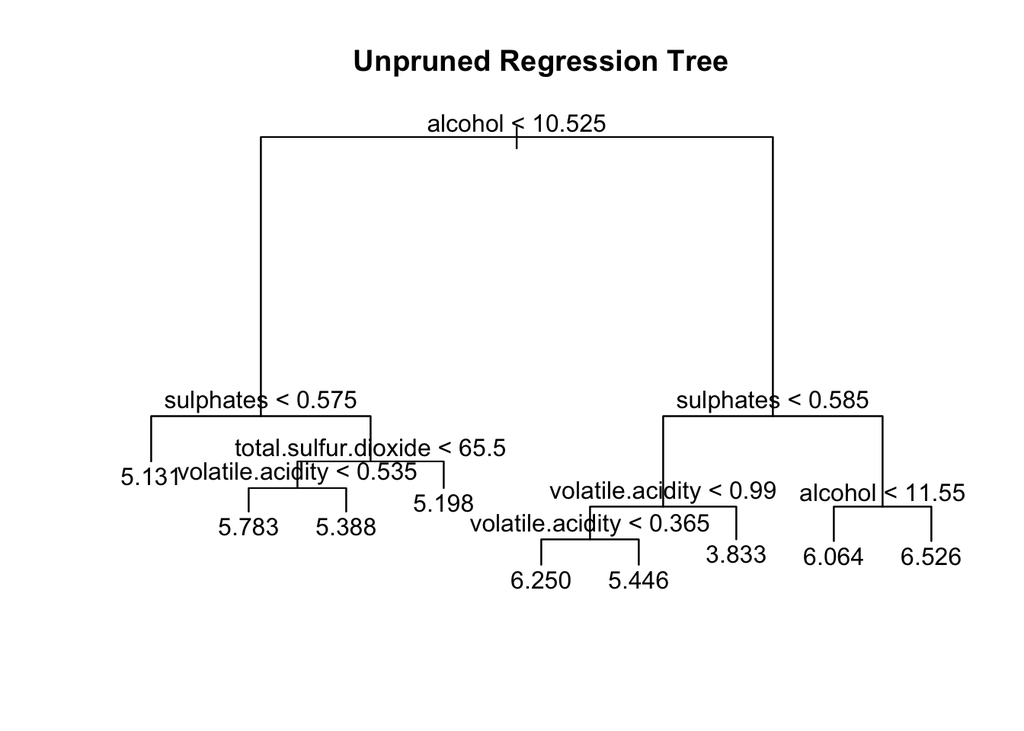

```r
plot(wineTree)
text(wineTree)
title(main="Unpruned Regression Tree")
```

```r
predictions <- predict(wineTree, newdata = testing_data)

test_mse <- mean((testing_data$quality - predictions)^2)
test_mse
```

```
## [1] 0.4441773
```

3. Single Regression Tree (Bootstrapped). Take a single bootstrap sample from your training set. Fit another regression tree using this bootstrap sample. Include a plot of this tree in your results. Briefly describe how this tree compared to the tree in problem(2). Compute the test MSE.

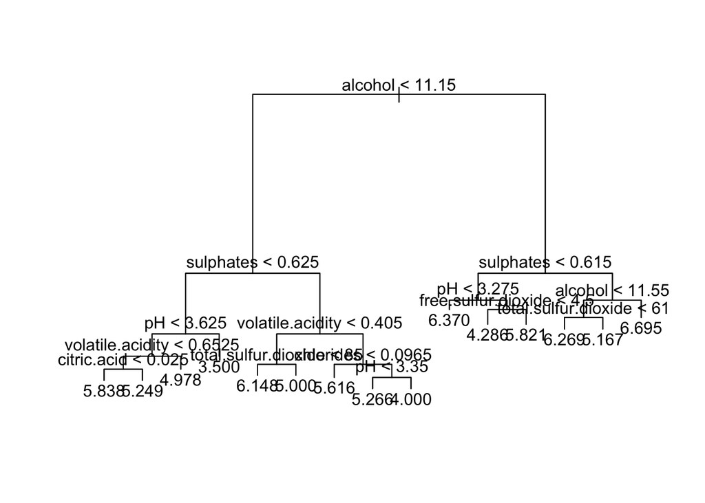

```r
bootstrap <- training_data[sample(nrow(training_data), replace = TRUE), ]

boot_wine_tree <- tree(quality ~., data = bootstrap)

plot(boot_wine_tree)
text(boot_wine_tree, pretty = 0)
```